# PA1_template

Helen

Friday, August 08, 2014

### Project introduction

This project uses data from activity monitoring device of a single anonymous individual within October and November, 2012. The device collects data at 5 minute intervals through out the day, and includes the number of steps taken in 5 minute intervals each day.

**Variables** included in this dataset are:

1. *steps* : Number of steps taking in a 5-minute interval (missing values are coded as NA)
2. *date* : The date on which the measurement was taken in YYYY-MM-DD format
3. *interval* : Identifier for the 5-minute interval in which measurement was taken

**^** *Special notes here : steps contains missing values (NA) and are treated differently in below sections. Please refer to information and comments from each individual section.*

Further details on project requirements and data source acknoledgement, please refer to [*Github page BY Roger D. Peng*](https://github.com/rdpeng/RepData_PeerAssessment1)

### 1. Loading and preprocess on raw data

This step performs the first phase preparation, including:

1.1 set working directory

1.2 download data file

1.3 read downloaded .csv file into a data frame

```r
raw<-read.csv(".\\activity.csv")
```

1.4 apply format on “date” column for later manupilation

```r
raw$date<-as.Date(raw$date)
```

1.5 load required package

Packages used in this project are **plyr**,**ggplot2**, and **lattice**. In coding, packages can be loaded up front. However for this documents,package calls actually happen when it’s required from each section.

### 2. Total number of steps taken per day

This section is required to ignore NA values on steps. `{r}ddply` function is used on imported dataset with NA removed to get a total number of steps by date.

```r
require(plyr)
total_steps<-ddply(raw[!is.na(raw$steps),], c("date"), summarize, steps = sum(steps))
```

A histogram plot can be made from returned data frame `{r}total_steps` using base graphic function `{r} hist(total_steps$steps,...)` which looks like below:

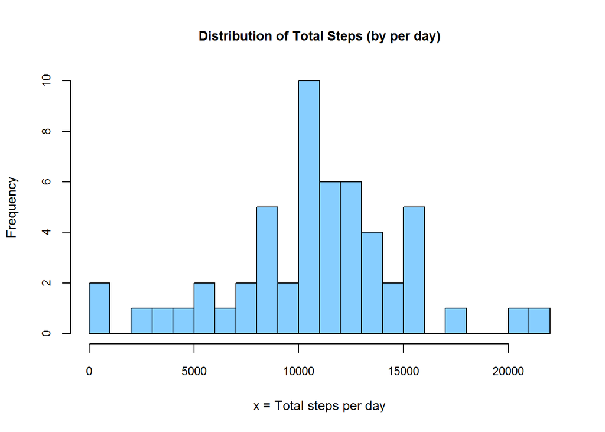

Continue working from the same dataset `{r}total_steps`, mean of steps equals

```
## [1] 10766
```

and median of steps equals

```
## [1] 10765
```

### 3. Average daily activity pattern

This section focuses on average pattern of steps in relation to 5-minute intervals for entire date range. Similar to above analysis,`{r}ddply` function is used, but instead of summarizing the total steps by date, now summarization takes the average by intervals across all dates where NA values are removed by arguments within `{r} mean()` operation.

```r
avg_int_steps<-ddply(raw, c("interval"), summarize, steps = mean(steps,na.rm=TRUE))
```

A time series plot of avg(steps) can be drawn by base graphic function `{r} plot(x,y,...)` where x is the interval measurements, and y is avg(steps) on each interval over entire observation date range (two months period). Annovations to the basic look i.e.aesthetic and geometric preferences can be added as “…” arguments.

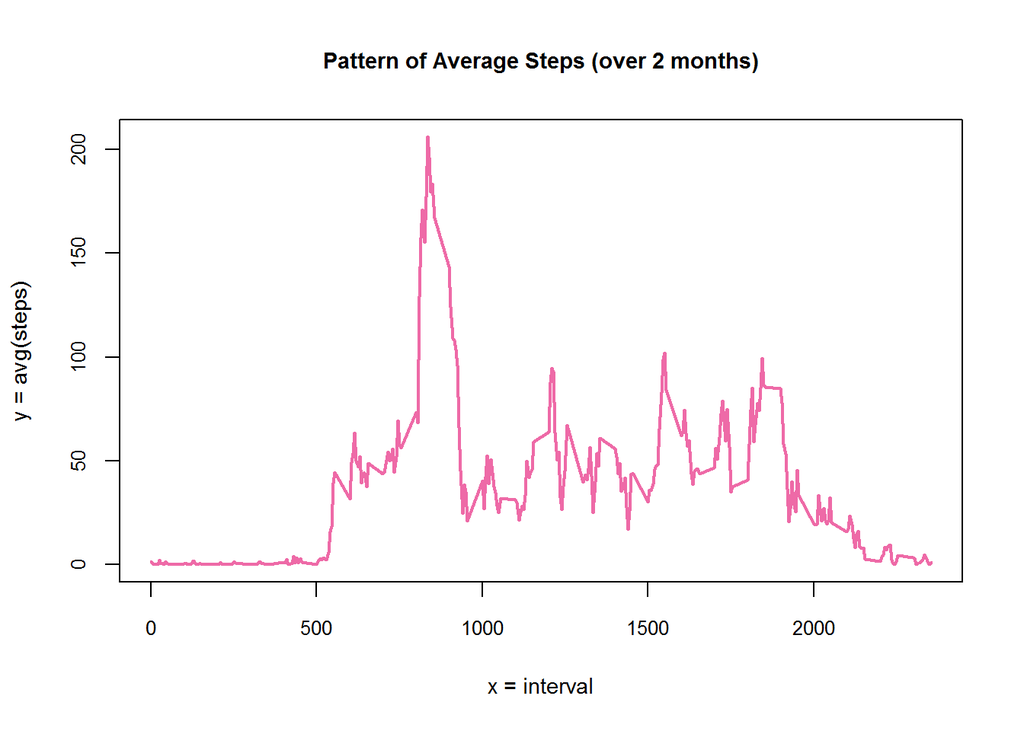

It’s not easy to measure statistics i.e.max/min from reading plots as above without extra annovation efforts, however below codes are quite handy, for example, to get max of Avg(steps):

```r
avg_int_steps[which.max(avg_int_steps$steps),]
```

```
##     interval steps
## 104      835 206.2
```

This clearly shows that the maximum of average steps by intervals happen at interval 835, and the average steps for this interval is 206.2 over 2 months observation.

### 4. Imputing Missing Values

This section aims at an approach to handle NA values by compensating or minimizing its impacts as well as make a more complete dataset.

Firstly, to understand how many measurements are experiencing NA values, a simple row count on the `{r} is.na()` subset of original dataset (recall as `{r} raw`) returns:

```
## [1] 2304
```

Secondly, to determine an approach to “recover” missing values, it’s been realized that some dates have all measurements from every intervals missing. Hence I decide to go with the average from overall period and feed it to NA values where it has the same intervals. This approach utilizes result from previous **STEP 3**.

To achieve this, a copy of original data is made and named as `{r} DRV_raw` . `{r} for` then looped through all intervals, and update missing values on derived data frame with average from *STEP 3* result. To be specific, it look like

```r
DRV_raw<-raw

for (i in avg_int_steps$interval) {
DRV_raw$steps[is.na(DRV_raw$steps)&DRV_raw$interval==i]<-avg_int_steps$steps[avg_int_steps$interval==i]
}
```

This new derived dataset now doesn’t contain any missing values. Again if similar transformations are applied with `{r}ddply` function call and the hist plotting *(refer to Step 2 from above)* now looks like below

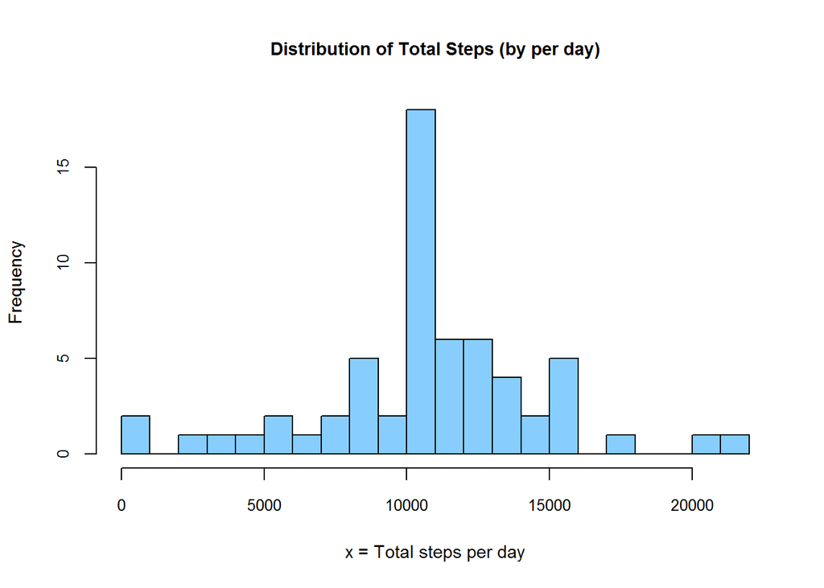

Again mean and median can be taken the same way. Mean is now

```
## [1] 10766
```

and median is now

```
## [1] 10766
```

As it’s hard to link the difference together without looking at the distribution side by side, function `{r} qplot(x,data,facets=~.,...)` from package **ggplot2** is quite powerful to put things like this together. A few transformations required to put derived and raw into one data frame, but separated by a facet (named [type] in my work), which produces below comparison look:

```
## stat_bin: binwidth defaulted to range/30. Use 'binwidth = x' to adjust this.
## stat_bin: binwidth defaulted to range/30. Use 'binwidth = x' to adjust this.
```

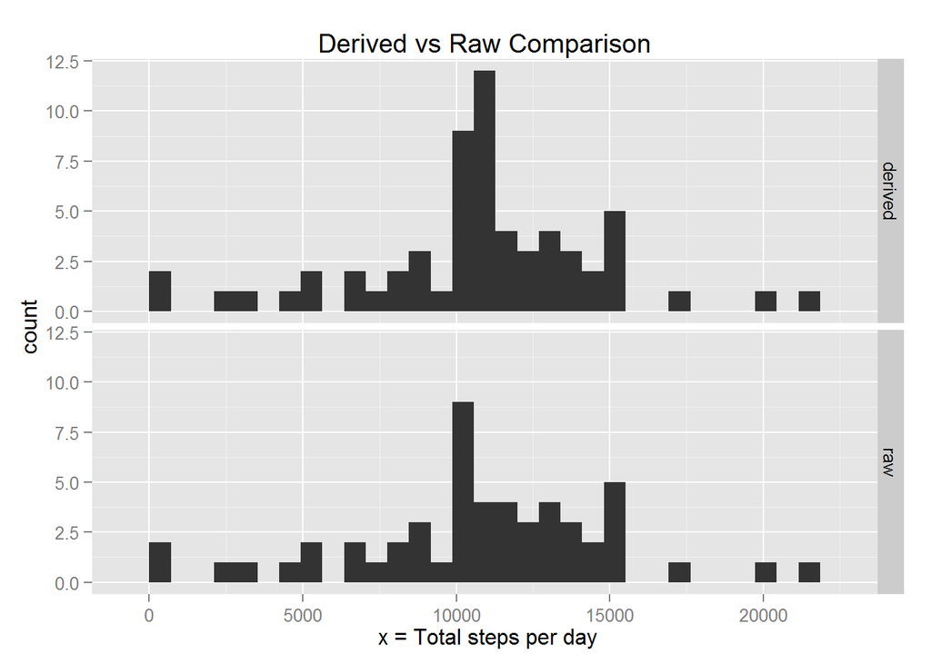

To draw a conclusion to this approach, NA impact to overall median is eliminated but the distribution of total steps pattern is shifted comparing to the raw data with NAs. I think which approach to choose is more a matter of analytical direction and goal to achieve.

### 5. Weekday/Weekend Analysis

Based on above derived data, this section compares average steps by intervals among two audience group: weekend and weekday. To achieve such purposed, some data formation are done to:

- get weekday/weekend by `{r} weekdays()` function
- apply `{r} ddply` to get the average by interval & weekday/weekend type
- factor this type for later plotting

```r
DRV_raw$weekday[weekdays(DRV_raw$date)=="Saturday"|weekdays(DRV_raw$date)=="Sunday"]<-"weekend"
DRV_raw$weekday[is.na(DRV_raw$weekday)]<-"weekday"

DRV_avg_int_steps<-ddply(DRV_raw, c("weekday","interval"), summarize, steps = mean(steps))
DRV_avg_int_steps<-transform(DRV_avg_int_steps,weekday=factor(weekday))
```

Once above transformation is completed, package **lattice** is required to produce pannels like below. Plotting function called is `{r} xyplot(y~x|f,data,...)` In this instance, dataset is `{r} DRV_avg_int_steps` with y = steps, x = interval and f = weekday, extra aesthetic and geometric arguments to follow in “…”.

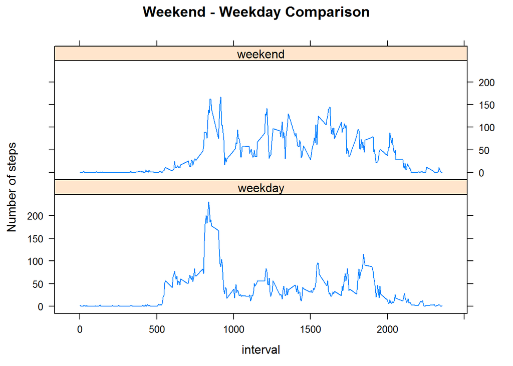

This is the end of this document.